# Bilan

## cadrage

### cadrage

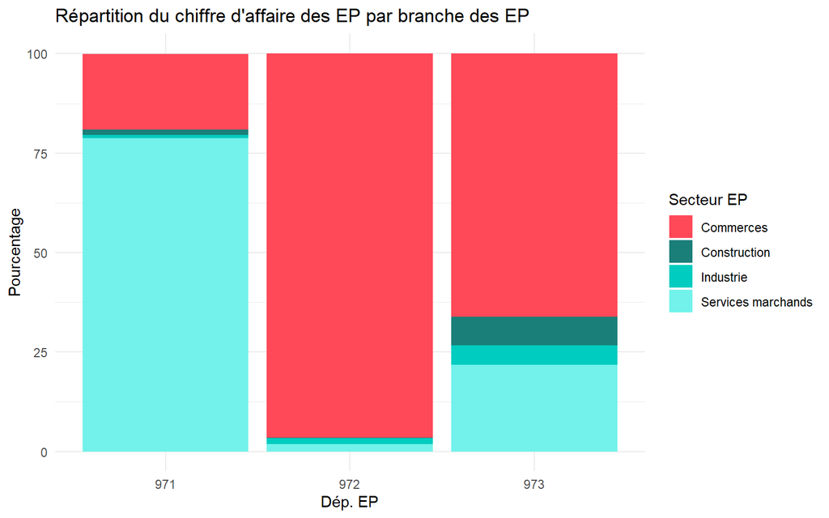

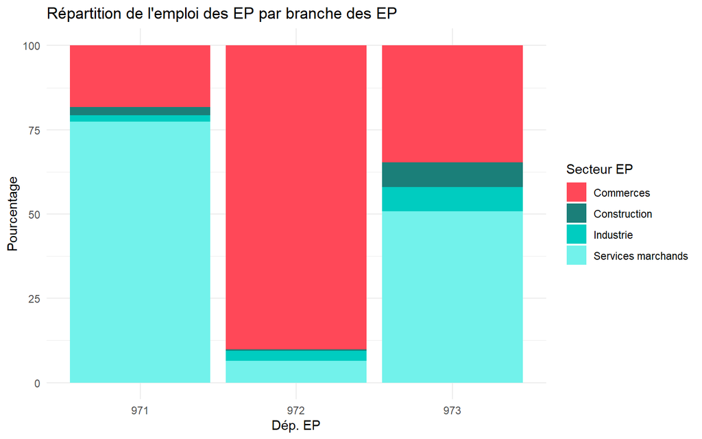

| Dép. EP | Secteur EP | Moyenne Effectif EP |
| --- | --- | --- |
| 971 | Commerces | 147 |
| 971 | Construction | 60 |
| 971 | Industrie | 37 |
| 971 | Services marchands | 659 |
| 972 | Commerces | 1667 |
| 972 | Construction | 41 |
| 972 | Industrie | 192 |
| 972 | Services marchands | 157 |
| 973 | Commerces | 74 |
| 973 | Construction | 31 |
| 973 | Industrie | 30 |
| 973 | Services marchands | 59 |

Et pour le 973 (Guyane), c’est clair que les commerces et les services marchands ont plus d’emplois que la construction ou l’industrie. Mais bon, c’est peut-être juste parce qu’il y a plus de touristes qui viennent faire des achats là-bas, rien de spécial.

En gros, les commerces et les services marchands dominent partout, mais ce n’est pas forcément parce que c’est plus lucratif.

### sous-partie1

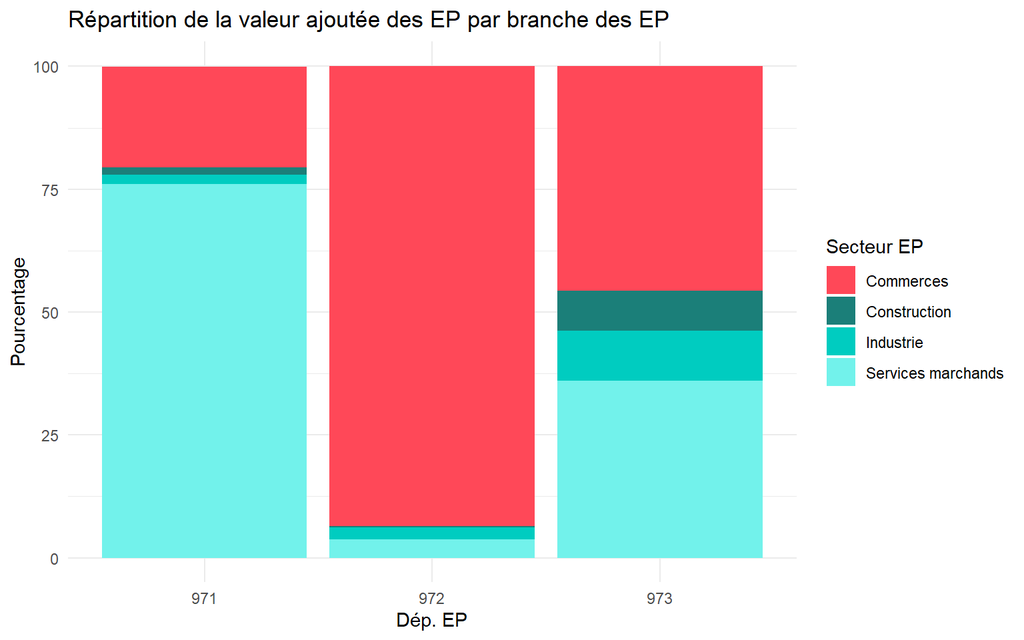

Alors, on a regardé les données des grandes entreprises aux Antilles et en Guyane. Dans le 971 (Guadeloupe), c’est clair que les commerces roulent sur l’or avec plus de 20% du chiffre d’affaires total. Les services marchands sont aussi super importants, ils balancent presque 80%. Par contre, la construction et l’industrie, c’est vraiment pas grand-chose.

Dans le 972 (Martinique), les commerces sont encore plus dominants avec presque 94% du chiffre d’affaires total. Les services marchands font un peu de bruit aussi, mais c’est vraiment rien comparé aux commerces. L’industrie et la construction, elles se battent pour les miettes.

Et enfin, le 973 (Guyane), les commerces tiennent encore une fois la barre avec plus de 45%. Mais cette fois, les services marchands ne sont pas loin derrière avec presque 36%. L’industrie et la construction, elles restent dans l’ombre.

En gros, les commerces c’est ce qui rapporte le plus de thunes partout, surtout en Martinique. Les services marchands sont aussi importants, mais pas autant que les commerces. L’industrie et la construction, elles restent dans l’ombre.

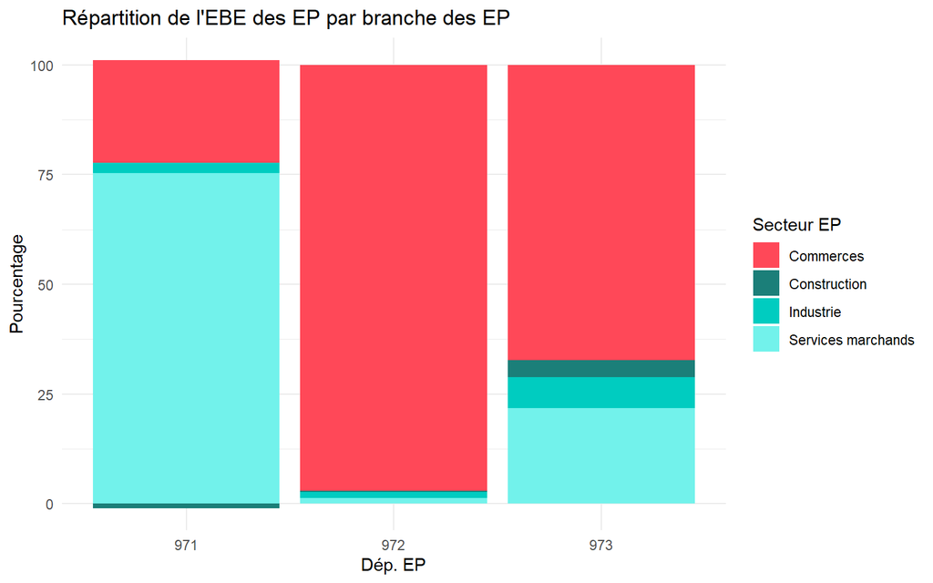

Les données montrent que dans le 971, c’est les “Services marchands” qui roulent sur l’or avec un excédent brut d’exploitation de 6152. Le reste des secteurs, comme la Construction et l’Industrie, ils peinent à joindre les deux bouts. Dans le 972, c’est pareil : les “Commerces” trustent presque tout le gâteau avec un EBE de 63578. Les autres secteurs, ils sont loin derrière. Enfin, dans le 973, les “Services marchands” et les “Commerces” se partagent la majeure partie des thunes. Bref, c’est clair que certains secteurs font plus de thunes que d’autres, mais ça dépend aussi du département.

## entreprises

### côté entreprises

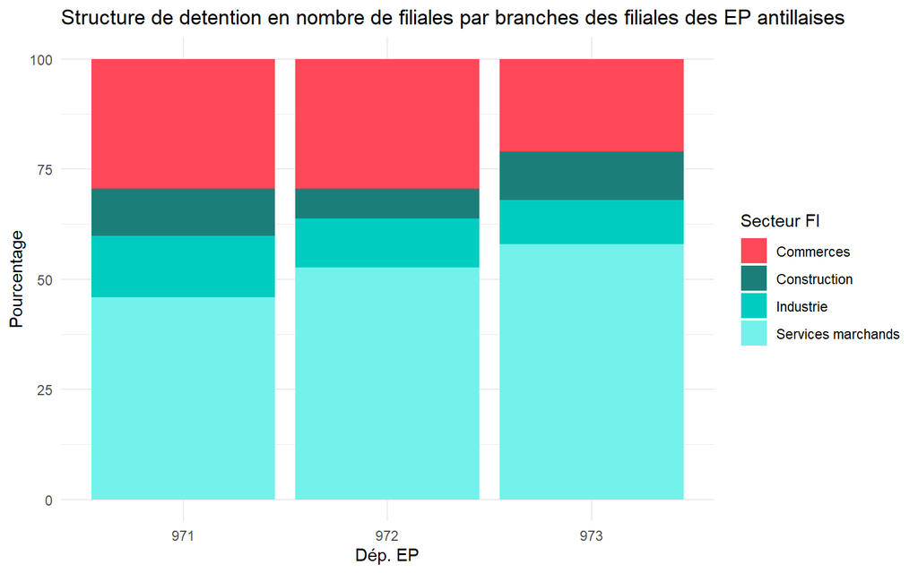

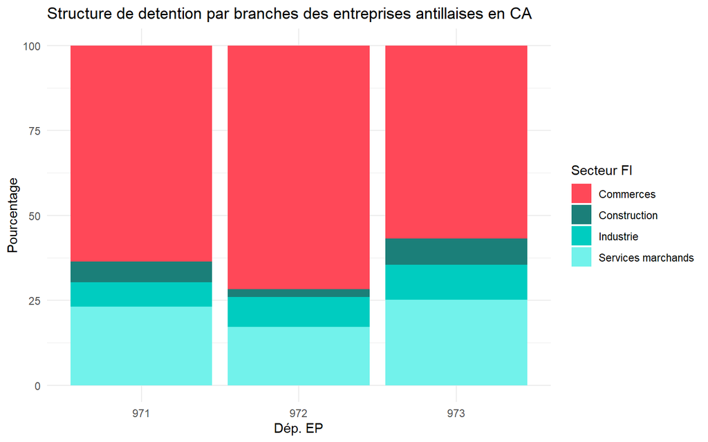

En Guyane (973), les Commerces sont encore en tête, avec presque 57% du chiffre d’affaires. La Construction et l’Industrie ne pèsent pas lourd, et les Services marchands non plus.

Bref, c’est clair que les Commerces roulent sur la concurrence aux Antilles et en Guyane. Mais bon, ça dépend de plein de trucs, hein ?

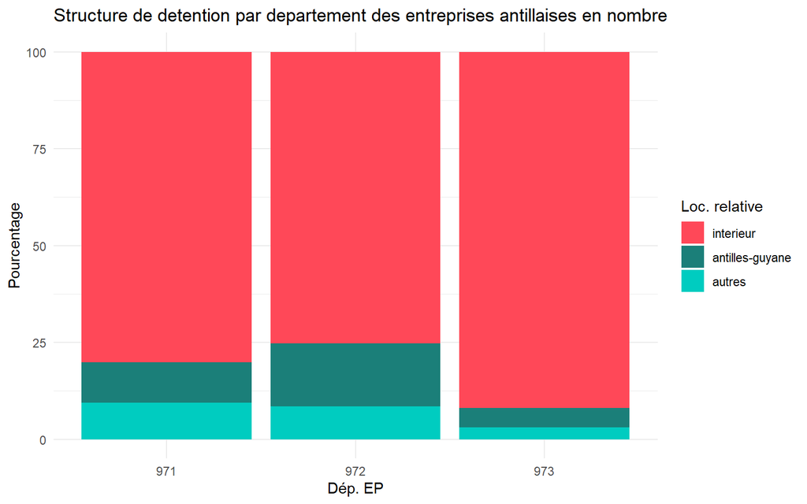

Alors, regarde bien les données. On voit que les grandes entreprises de Guadeloupe (971) ont beaucoup de filiales à l’intérieur des Antilles et Guyane, avec plus de 80% des thunes gagnées par ces filiales. Les autres départements comme la Martinique (972) suivent un peu le même schéma, mais avec moins d’impact. Par contre, en Guyane (973), c’est vraiment les filiales locales qui dominent, avec presque 92% des thunes gagnées. C’est sûr que chaque région a ses particularités, et peut-être que la Guyane, elle préfère garder tout pour elle, ou alors c’est juste une question de proximité. En tout cas, ça montre bien que les liens entre filiales et grandes entreprises varient d’un endroit à l’autre.

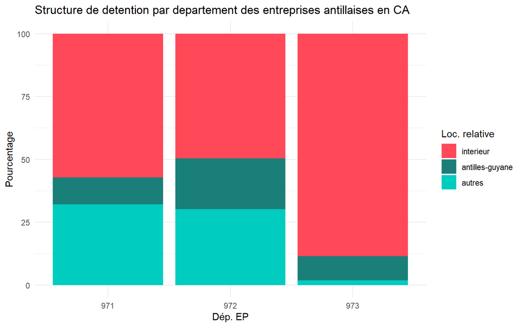

Alors, si on regarde ces données, on voit que les grandes entreprises aux Antilles et en Guyane, elles ont leurs filiales un peu partout. Mais ce qui est clair, c’est qu’elles préfèrent garder leurs filiales dans le même département. Par exemple, pour la Guadeloupe (971), plus de la moitié des thunes gagnées par les filiales viennent de l’intérieur du département. Idem pour la Martinique (972).

## filiales

### côté filiales

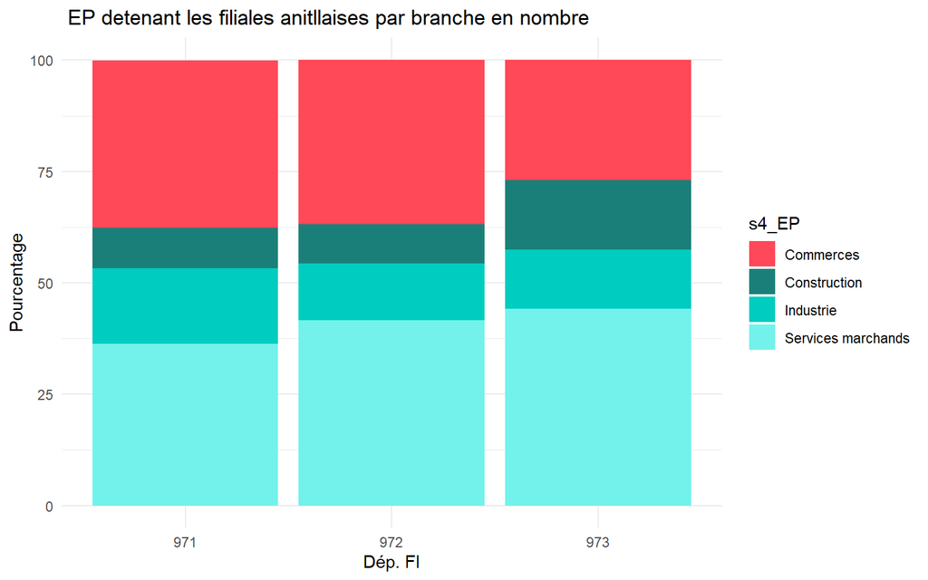

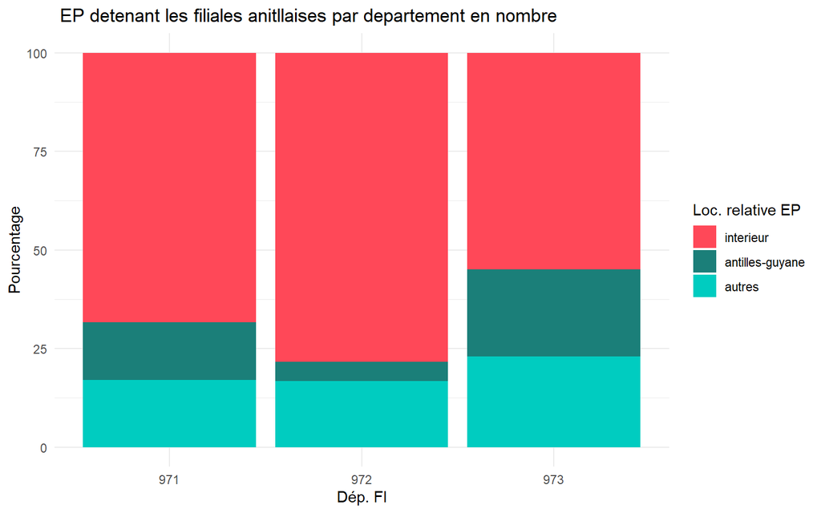

Alors, on a regardé comment les grandes entreprises (EP) tiennent leurs filiales dans les Antilles et la Guyane. En gros, c’est comme si chaque département avait son propre jeu de cartes.

Pour le 972 (Martinique), c’est pareil mais en plus fort : presque quatre-vingts pourcents des filiales sont gérées par des EP locales, et les autres viennent d’ailleurs.

Et pour le 973 (Guyane), c’est un peu différent : la moitié des filiales sont sous le contrôle de EP guyanaises, et le reste est partagé entre les Antilles et les autres.

Mais bon, les chiffres, c’est juste une façon de voir les choses. En vrai, chaque département a ses propres jeux de pouvoir et ça change tout le temps.

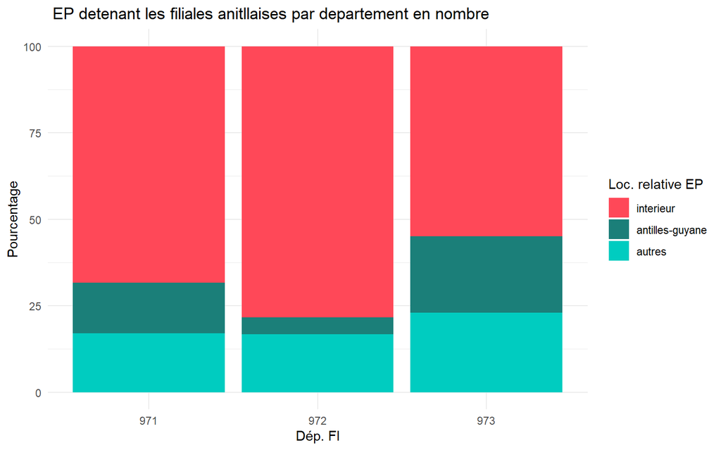

Salut, alors on a regardé les données sur les grandes entreprises (EP) qui tiennent des filiales dans les Antilles et en Guyane. C’est intéressant de voir que dans le département 971 (Guadeloupe), la plupart des filiales sont contrôlées par des EP d’ici même, avec presque 68% du poids total. En gros, ça veut dire que les grandes entreprises locales dominent le game en Guadeloupe. Par contre, en Martinique (972), c’est encore plus flagrant : elles contrôlent environ 78% des filiales. C’est comme si elles avaient pris possession du territoire. En Guyane (973), c’est un peu moins marqué, avec environ 55% des filiales contrôlées par des EP locales.

Ce qui est drôle, c’est qu’on pourrait penser que les entreprises des Antilles-Guyane ou d’ailleurs auraient plus de poids, mais non, les locaux tiennent le haut du pavé. Peut-être parce qu’ils connaissent mieux le terrain et savent comment naviguer dans ce marché spécifique. En tout cas, c’est clair que les grandes entreprises locales sont bien implantées et ne laissent pas beaucoup de place aux autres.

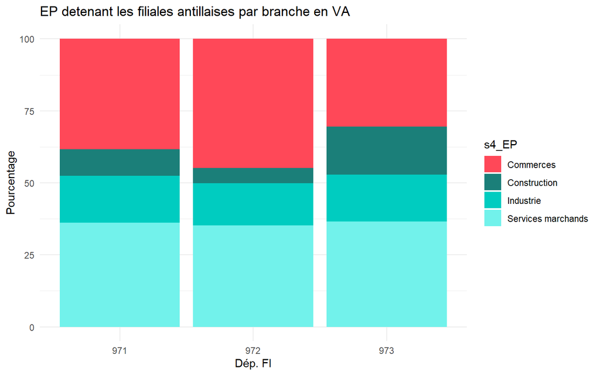

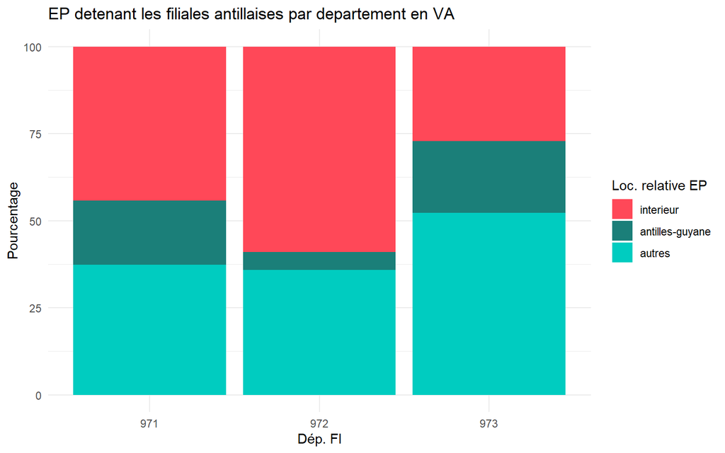

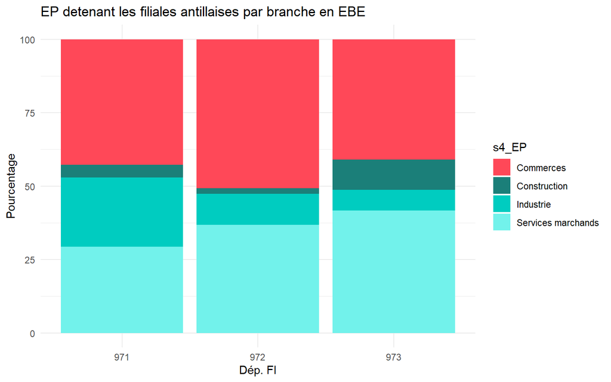

Alors, c’est clair que dans ces données, on voit que les Commerces raflent le plus de thunes dans les Antilles et en Guyane. Que ce soit à Guadeloupe (971), Martinique (972) ou Guyane (973), les Commerces trustent une bonne part du gâteau. En Guyane, c’est un peu serré avec les Services marchands qui ne sont pas loin derrière. Les autres branches comme la Construction et l’Industrie, elles se contentent des miettes, même si en Guadeloupe et Martinique, elles font quand même leur petit effet. Mais bon, face aux Commerces, c’est clair que ça ne pèse pas lourd.

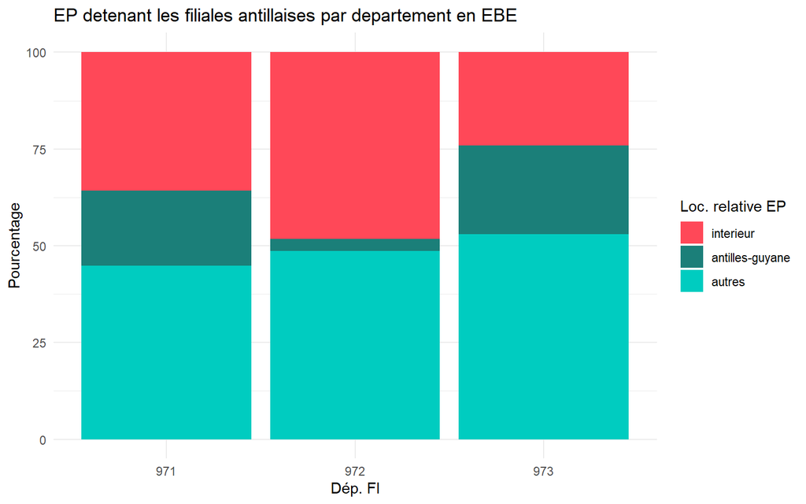

En gros, les grandes entreprises préfèrent avoir leurs filiales dans le même coin, mais y a des exceptions. C’est peut-être parce qu’ils veulent garder un œil dessus ou que c’est plus simple pour eux. Mais bon, on sait pas vraiment pourquoi, et c’est pas toujours clair non plus.